# TUTORIAL: One dataset, four meta-analyses: synthesising mean effects, within-population variability, and between-population heterogeneity in ecology

#### lnCVR

```r
form_ls_ma2 <- bf(lnCVR ~ 1 + Org.fertilizer.type +
                    (1|study_ID) + # this is u_l (the between-study effect)
                    (1|gr(effect_size_ID, cov = vcv)), # this is m (sampling error)
                  sigma ~ 1 +  Org.fertilizer.type
                  )

# generate default priors
prior_ls_ma2 <- default_prior(form_ls_ma2,
                              data=dat,
                              data2=list(vcv=vcv),
                              family=gaussian())

prior_ls_ma2$prior[5] = "constant(1)" # meta-analysis assumes

# fitting model
fit_ls_ma2 <- brm(
  formula = form_ls_ma2,
  data = dat,
  data2 = list(vcv=vcv),
  chains = 2,
  cores = 2,
  iter = 6000,
  warmup = 3000,
  prior = prior_ls_ma2,
  control = list(adapt_delta=0.95, max_treedepth=15)
  )
summary(fit_ls_ma2)
# Family: gaussian
#   Links: mu = identity; sigma = log
# Formula: lnCVR ~ 1 + Org.fertilizer.type + (1 | study_ID) + (1 | gr(effect_size_ID, cov = vcv))
#          sigma ~ 1 + Org.fertilizer.type
#    Data: dat (Number of observations: 318)
#   Draws: 2 chains, each with iter = 6000; warmup = 3000; thin = 1;
#          total post-warmup draws = 6000
#
# Multilevel Hyperparameters:
# ~effect_size_ID (Number of levels: 318)
#               Estimate Est.Error l-95% CI u-95% CI Rhat Bulk_ESS Tail_ESS
# sd(Intercept)     1.00      0.00     1.00     1.00   NA       NA       NA
#
# ~study_ID (Number of levels: 36)
#               Estimate Est.Error l-95% CI u-95% CI Rhat Bulk_ESS Tail_ESS
# sd(Intercept)     0.26      0.08     0.12     0.42 1.00     1557     2388
#
# Regression Coefficients:
#                                Estimate Est.Error l-95% CI u-95% CI Rhat Bulk_ESS Tail_ESS
# Intercept                          0.30      0.09     0.13     0.47 1.00     5124     4713
# sigma_Intercept                   -0.84      0.13    -1.10    -0.60 1.00     1309     2382
# Org.fertilizer.typeplant           0.08      0.12    -0.16     0.31 1.00     4922     5061
# sigma_Org.fertilizer.typeplant     0.51      0.18     0.17     0.86 1.00     1716     3396
#
# Draws were sampled using sampling(NUTS). For each parameter, Bulk_ESS
# and Tail_ESS are effective sample size measures, and Rhat is the potential
# scale reduction factor on split chains (at convergence, Rhat = 1).
```

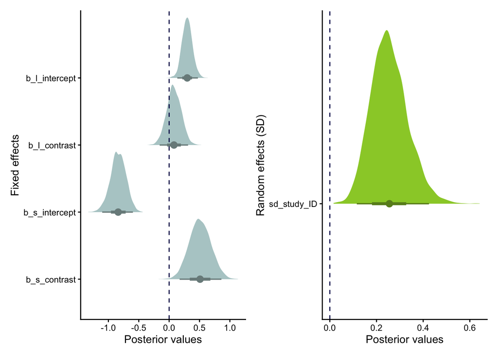

For lnCVR, the location component indicated that organic systems tend to exhibit higher mean-corrected variability under animal-based fertilisers ($\beta^{(l)}_{\text{animal}} = 0.30$, 95% CrI = [0.13, 0.47]), corresponding to an average CV ratio of $\exp(0.30) \approx 1.35$, roughly 35% higher variability in organic relative to conventional systems.

The contrast coefficient for fertiliser type in the location component was small and highly uncertain ($\beta^{(l)}_{\text{plant-animal}} = 0.08$, 95% CrI = [-0.16, 0.31]), suggesting that fertiliser category does not systematically shift the average mean-corrected within-group-variability contrast between organic and conventional systems.

In contrast, the scale component showed a larger residual-scale component for plant-based fertilisers. Residual heterogeneity was substantially larger under plant-based fertilisers ($\beta^{(s)}_{\text{plant-animal}} = 0.51$, 95% CrI = [0.17, 0.86]), corresponding to a multiplicative increase in residual variability of approximately 67% ($\exp(0.51) \approx 1.67$). Under this model, the implied residual standard deviation for lnCVR under plant-based fertilisers is $\sigma \approx \exp(-0.84 + 0.51) \approx 0.72$.

Thus, while the expected magnitude of the mean-corrected within-group-variability contrast (lnCVR) is broadly similar across fertiliser categories, the represented comparisons have a wider residual spread under plant-based fertilisers. This residual-scale contrast concerns consistency within the analysed studies; it does not by itself establish poorer transferability to a new study.

**B and C. Random effects/Correlated random effects in location and scale components**

The models presented here extend the basic location–scale meta-regression by allowing study-level heterogeneity to operate not only on the mean effect size, but also on the residual variance.

These models are included for completeness and to illustrate the flexibility of `brms`. In practice, they are often difficult to fit reliably and should be treated as advanced extensions rather than default choices. Accordingly, we provide example code but do not interpret the results in detail.

For transparency, examples in which the models were run but failed to converge are also documented in this [online tutorial](https://itchyshin.github.io/location-scale_meta-analysis/). You can also find more examples of complex location-scale models in another [online tutorial](https://ayumi-495.github.io/Eco_location-scale_model/), though these are not specific to meta-analysis.

**1. with random effects in scale component**

In the model with the random effects in the scale component, we can include random effects in the scale component, allowing residual heterogeneity to vary across studies. If we want to specify such a model, we can do so as follows:

```r
sigma ~ 1 + Org.fertilizer.type + (1 | study_ID)
```

This specification allows the residual variance to vary across studies, in addition to allowing study-level variation in the mean effect size via the location component. Conceptually, the location component models how the mean effect size varies with the moderator and across studies. The scale component models how the amount of unexplained variability differs across studies and fertiliser types.

Random effects in the location and scale components are assumed to be independent in this formulation.

**2. Correlated random effects in location and scale components**

The next model further extends the previous formulation by allowing correlated random effects between the location and scale components. For example, if we want to consider potential correlations between study-level deviations in mean effect sizes and deviations in residual variance, we can specify the model as follows:

```r
(1 | p | study_ID)
```

This specification allows the model to estimate the correlation between study-level deviations in the mean effect size and deviations in residual variance.

For example, a negative correlation would indicate that studies with larger mean effects tend to show lower residual variability, whereas a positive correlation would suggest the opposite. Such relationships are conceptually appealing and biologically interpretable in some contexts.

However, this model is computationally demanding and highly sensitive to prior specification and data structure. In applied meta-analyses, it frequently exhibits convergence problems or weakly identified correlation parameters.

## glmmTMB

In contrast to `metafor`, `glmmTMB` allows us to include random effects in both location and scale components - we demonstrate how to fit a location-scale meta-regression model using `glmmTMB`.

But it should be mentioned that `glmmTMB` does not support correlated random effects between location and scale components, so the third model presented above cannot be implemented using `glmmTMB`.

Again, the same as `brms`, we focus on a location–scale meta-regression model with fixed effects in the scale component.

**NoteKeep in your mind…**

In the location–scale models by `glmmTMB`, dispersion parameters are modelled on the log standard deviation scale ($\ln(\sigma)$). All coefficients for the scale component should be interpreted as effects on the log standard deviation, not on the variance.

### A. Only fixed effects in scale component

In `glmmTMB`, the location–scale structure is implemented by separating the model into a *conditional* component and a *dispersion* component. The conditional model specifies the mean structure of the response (location), while the dispersion model specifies how the residual variance changes as a function of predictors (scale). Note that the dispersion model in `glmmTMB` does not describe an additional random effect, but rather models heteroscedasticity in the residual variance on the log scale.

#### lnRR

```r
dat$effect_size_ID <- factor(dat$effect_size_ID)
dat$g <- factor(1)
vcv <- diag(dat$var.lnRR)
row.names(vcv) <- colnames(vcv) <- dat$effect_size_ID

glmm_lnRR1 <- glmmTMB(lnRR ~ 1 + Org.fertilizer.type + (1 | study_ID) +
                      equalto(0 + effect_size_ID|g, vcv),
                  dispformula = ~ 1 + Org.fertilizer.type, # scale component
                  data = dat,
                  REML = TRUE)
summary(glmm_lnRR1)
#  Family: gaussian  ( identity )
# Formula:          lnRR ~ 1 + Org.fertilizer.type + (1 | study_ID) + equalto(0 +      effect_size_ID | g, vcv)
# Dispersion:            ~1 + Org.fertilizer.type
# Data: dat
#
#       AIC       BIC    logLik -2*log(L)  df.resid
#     230.9     249.7    -110.5     220.9       313
#
# Random effects:
#
# Conditional model:
#  Groups   Name             Variance  Std.Dev. Corr
#  study_ID (Intercept)      0.0608129 0.24660
#  g        effect_size_ID33 0.0047213 0.06871
#           effect_size_ID34 0.0426425 0.20650  0.00
#           effect_size_ID35 0.0698313 0.26426  0.00 0.00
#           effect_size_ID36 0.0798567 0.28259  0.00 0.00 0.00
#           effect_size_ID37 0.0837435 0.28938  0.00 0.00 0.00 0.00
#           effect_size_ID39 0.0095870 0.09791  0.00 0.00 0.00 0.00 0.00
#           effect_size_ID40 0.0091520 0.09567  0.00 0.00 0.00 0.00 0.00 0.00
#           effect_size_ID42 0.0363323 0.19061  0.00 0.00 0.00 0.00 0.00 0.00 0.00
#           effect_size_ID44 0.0331452 0.18206  0.00 0.00 0.00 0.00 0.00 0.00 0.00 0.00
#           effect_size_ID45 0.0012338 0.03513  0.00 0.00 0.00 0.00 0.00 0.00 0.00 0.00 0.00
#           ...              ...       ...      ...  ...  ...  ...  ...  ...  ...  ...  ...  ...
#  Residual                         NA      NA
# Number of obs: 318, groups:  study_ID, 36; g, 1
#
# Conditional model:
#                          Estimate Std. Error z value Pr(>|z|)
# (Intercept)              -0.26791    0.05379  -4.981 6.33e-07 ***
# Org.fertilizer.typeplant -0.13991    0.05897  -2.373   0.0177 *
# ---
# Signif. codes:  0 ‘***’ 0.001 ‘**’ 0.01 ‘*’ 0.05 ‘.’ 0.1 ‘ ’ 1
#
# Dispersion model:
#                          Estimate Std. Error z value Pr(>|z|)
# (Intercept)              -1.35445    0.07922 -17.097   <2e-16 ***
# Org.fertilizer.typeplant  0.17055    0.09928   1.718   0.0858 .
```

#### lnCVR

```r
library(glmmTMB)
dat$effect_size_ID <- factor(dat$effect_size_ID)
dat$g <- factor(1)
vcv <- diag(dat$var.lnCVR)
row.names(vcv) <- colnames(vcv) <- dat$effect_size_ID

glmm_lnCVR1 <- glmmTMB(lnCVR ~ 1 + Org.fertilizer.type + (1 | study_ID) +
                        equalto(0 + effect_size_ID|g, vcv),
                      dispformula = ~ 1 + Org.fertilizer.type,
                      data = dat,
                      REML = TRUE)
summary(glmm_lnCVR1)
#  Family: gaussian  ( identity )
# Formula:          lnCVR ~ 1 + Org.fertilizer.type + (1 | study_ID) + equalto(0 +      effect_size_ID | g, vcv)
# Dispersion:             ~1 + Org.fertilizer.type
# Data: dat
#
#       AIC       BIC    logLik -2*log(L)  df.resid
#     885.5     904.3    -437.7     875.5       313
#
# Random effects:
#
# Conditional model:
#  Groups   Name             Variance  Std.Dev. Corr
#  study_ID (Intercept)      0.05551  0.2356
#  g        effect_size_ID33 0.11583  0.3403
#           effect_size_ID34 0.29264  0.5410   0.00
#           effect_size_ID35 0.31983  0.5655   0.00 0.00
#           effect_size_ID36 0.32986  0.5743   0.00 0.00 0.00
#           effect_size_ID37 0.33374  0.5777   0.00 0.00 0.00 0.00
#           effect_size_ID39 0.12070  0.3474   0.00 0.00 0.00 0.00 0.00
#           effect_size_ID40 0.12026  0.3468   0.00 0.00 0.00 0.00 0.00 0.00
#           effect_size_ID42 0.28633  0.5351   0.00 0.00 0.00 0.00 0.00 0.00 0.00
#           effect_size_ID44 0.28315  0.5321   0.00 0.00 0.00 0.00 0.00 0.00 0.00 0.00
#           effect_size_ID45 0.25123  0.5012   0.00 0.00 0.00 0.00 0.00 0.00 0.00 0.00 0.00
#           ...              ...       ...      ...  ...  ...  ...  ...  ...  ...  ...  ...  ...
#  Residual                         NA      NA
# Number of obs: 318, groups:  study_ID, 36; g, 1
#
# Conditional model:
#                          Estimate Std. Error z value Pr(>|z|)
# (Intercept)               0.29891    0.08215   3.638 0.000274 ***
# Org.fertilizer.typeplant  0.08455    0.11985   0.705 0.480515
# ---
# Signif. codes:  0 ‘***’ 0.001 ‘**’ 0.01 ‘*’ 0.05 ‘.’ 0.1 ‘ ’ 1
#
# Dispersion model:
#                          Estimate Std. Error z value Pr(>|z|)
# (Intercept)              -0.8366     0.1303   -6.422 1.35e-10 ***
# Org.fertilizer.typeplant  0.5194     0.1777    2.923  0.00346 **
```

### B. Random effects in location and scale components

If you want to include random effects in the scale component, you just need to insert them to the `dispformula` part of the model.

```r
dat$effect_size_ID <- factor(dat$effect_size_ID)
dat$g <- factor(1)
vcv <- diag(dat$var.lnRR)
row.names(vcv) <- colnames(vcv) <- dat$effect_size_ID

glmm_lnRR2 <- glmmTMB(lnRR ~ 1 + Org.fertilizer.type + (1 | study_ID) +
                        equalto(0 + effect_size_ID|g, vcv),
                      dispformula = ~ 1 + Org.fertilizer.type + (1 | study_ID),
                      data = dat,
                      REML = TRUE)
summary(glmm_lnRR2)
#  Family: gaussian  ( identity )
# Formula:          lnRR ~ 1 + Org.fertilizer.type + (1 | study_ID) + equalto(0 +
#     effect_size_ID | g, vcv)
# Dispersion:            ~1 + Org.fertilizer.type + (1 | study_ID)
# Data: dat
#
#       AIC       BIC    logLik -2*log(L)  df.resid
#     177.4     199.9     -82.7     165.4       312
#
# Random effects:
#
# Conditional model:
#  Groups   Name             Variance  Std.Dev. Corr
#  study_ID (Intercept)      0.0570683 0.23889
#  g        effect_size_ID33 0.0047213 0.06871
#           effect_size_ID34 0.0426425 0.20650  0.00
#           effect_size_ID35 0.0698313 0.26426  0.00 0.00
#           effect_size_ID36 0.0798567 0.28259  0.00 0.00 0.00
#           effect_size_ID37 0.0837435 0.28938  0.00 0.00 0.00 0.00
#           effect_size_ID39 0.0095870 0.09791  0.00 0.00 0.00 0.00 0.00
#           effect_size_ID40 0.0091520 0.09567  0.00 0.00 0.00 0.00 0.00 0.00
#           effect_size_ID42 0.0363323 0.19061  0.00 0.00 0.00 0.00 0.00 0.00 0.00
#           effect_size_ID44 0.0331452 0.18206  0.00 0.00 0.00 0.00 0.00 0.00 0.00 0.00
#           effect_size_ID45 0.0012338 0.03513  0.00 0.00 0.00 0.00 0.00 0.00 0.00 0.00 0.00
#           ...              ...       ...      ...  ...  ...  ...  ...  ...  ...  ...  ...  ...
#  Residual                         NA      NA
# Number of obs: 318, groups:  study_ID, 36; g, 1
#
# Dispersion model:
#  Groups   Name        Variance Std.Dev.
#  study_ID (Intercept) 0.06081  0.2466
#  Residual                  NA      NA
# Number of obs: 318, groups:  study_ID, 36
#
# Conditional model:
#                          Estimate Std. Error z value Pr(>|z|)
# (Intercept)              -0.26476    0.04887  -5.417 6.05e-08 ***
# Org.fertilizer.typeplant -0.11847    0.04545  -2.607  0.00914 **
# ---
# Signif. codes:  0 ‘***’ 0.001 ‘**’ 0.01 ‘*’ 0.05 ‘.’ 0.1 ‘ ’ 1
#
# Dispersion model:
#                          Estimate Std. Error z value Pr(>|z|)
# (Intercept)               -1.6225     0.1147  -14.14  < 2e-16 ***
# Org.fertilizer.typeplant   0.4022     0.1406    2.86  0.00424 **
```

# Extension: Where does heterogeneity occur?

This extension addresses a different question from the average effect: whether category-specific heterogeneity is attributable mainly to differences **among studies** or to differences **among comparisons within studies**. We distinguish these components because a wider residual distribution supports a statement about consistency among represented comparisons, whereas a wider study distribution is the component relevant to variation in a new study’s mean effect.

The extension uses the cereal subset with plant- and animal-based organic fertilisers. The full analysis contains 318 effects from 36 studies. Six studies contribute both fertiliser categories (86 effects); a matched subset excluding those studies contains 232 effects from 30 studies. The latter restriction makes fertiliser category constant within every study, which is required for the direct study-scale formulation below.

## Starting comparator: residual location–scale model

Start with the residual location–scale model fitted above. It allows animal and plant fertilisers to have different residual SDs, but keeps the between-study SD the same for both. Let $i$ identify an effect size, $j$ its study, and $g$ its fertiliser category ($A$ for animal, $P$ for plant). The observed effect size is

$$y_{ij}=\mu_g+u_j+e_{ij}+m_{ij}.$$

Here $\mu_g$ is the expected effect for that fertiliser category, $u_j$ is the study’s departure from that expectation, $e_{ij}$ is the effect’s remaining departure within the study, and $m_{ij}$ is sampling error. The random departures are centred on zero:

$$\begin{aligned}
u_j &\sim \mathcal N(0,\tau^2), &&\text{between studies},\\
e_{ij} &\sim \mathcal N(0,\sigma_g^2), &&\text{within studies},\\
m_{ij} &\sim \mathcal N(0,v_{ij}), &&\text{sampling error}.
\end{aligned}$$

The second argument of $\mathcal N$ is a variance: $\tau$ and $\sigma_g$ are SDs, whereas $v_{ij}$ is the known sampling variance. Only the residual SD, $\sigma_g$, changes with fertiliser category here. A difference in this component alone does not establish a difference in between-study heterogeneity. The code above fits this starting model using `metafor`, `glmmTMB`, and `brms`.

## General multilevel location–scale model

We can model the between-study SD in the same way as the residual SD. Written with one moderator in each sub-model, the extension is

$$\begin{aligned}
y_{ij} &= \beta_0+\beta_1x_{ij}+u_j+e_{ij}+m_{ij},
&&\text{expected effect and departures},\\
\log(\tau_j) &= \gamma_{u0}+\gamma_{u1}z_j,
&&\text{between-study SD},\\
\log(\sigma_{ij}) &= \gamma_{e0}+\gamma_{e1}w_{ij},
&&\text{within-study SD}.
\end{aligned}$$

The random departures now have distributions $u_j\sim\mathcal N(0,\tau_j^2)$ and $e_{ij}\sim\mathcal N(0,\sigma_{ij}^2)$. The three lines ask different questions: does the expected effect change, does the spread among studies change, and does the spread within studies change? The moderators $x_{ij}$, $z_j$, and $w_{ij}$ can be the same variable or different variables; further moderator terms can be added to each line. The coefficients $\beta_1$, $\gamma_{u1}$, and $\gamma_{e1}$ describe those three changes. Both scale sub-models use log SD, so exponentiating a scale coefficient gives the multiplicative change in that SD per unit of its moderator.

Because $u_j$ is one shared study effect, its scale predictor $z_j$ must have one value per study. The residual-scale predictor $w_{ij}$ can vary among effects within a study. For fertiliser, the direct study-scale formulation therefore uses the 30 single-category studies. The next formulation also accommodates the six studies containing both categories. Sampling error remains separate: its known variances, and any sampling covariances, belong in the sampling covariance matrix `V` supplied to the model.

## Categorical random coefficients are a location–scale special case

Instead of one shared study effect $u_j$, allow a study to have an animal-fertiliser effect $u_{jA}$ and a plant-fertiliser effect $u_{jP}$. Each observation uses the effect for its own category:

$$y_{ij}=\begin{cases}
\mu_A+u_{jA}+e_{ij}+m_{ij}, & \text{animal fertiliser},\\
\mu_P+u_{jP}+e_{ij}+m_{ij}, & \text{plant fertiliser}.
\end{cases}$$

The study SDs are $\operatorname{SD}(u_{jA})=\tau_A$ and $\operatorname{SD}(u_{jP})=\tau_P$; the residual SDs are $\sigma_A$ and $\sigma_P$. This is called a *categorical random-coefficient model*. It is also *heteroscedastic*: it allows the amount of variation to differ between categories.

The two study SDs can instead be expressed through scale coefficients:

$$\begin{aligned}
\log(\tau_A)&=\gamma_0, & \tau_A&=\exp(\gamma_0),\\
\log(\tau_P)&=\gamma_0+\gamma_1, & \tau_P&=\exp(\gamma_0+\gamma_1).
\end{aligned}$$

These are two ways to describe the same pair of category-specific SDs: estimating them separately or describing their difference on the log-SD scale. They give the same likelihood on the single-category subset when the location, residual, and sampling-error specifications match. For studies containing both categories, the relationship between $u_{jA}$ and $u_{jP}$ must also be specified; two SDs alone do not define that covariance.

A familiar alternative is random-intercept and random-slope coding, with animal coded 0 and plant coded 1. The study’s animal effect is then $u_{0j}$, and its plant effect is $u_{0j}+u_{1j}$. The random slope $u_{1j}$ is the study-specific departure in the plant-minus-animal contrast, not the plant effect itself. Consequently,

$$\operatorname{Var}(u_{jP})=\operatorname{Var}(u_{0j})+
\operatorname{Var}(u_{1j})+2\operatorname{Cov}(u_{0j},u_{1j}).$$

Here $\operatorname{Cov}$ measures whether the study-specific animal effect and plant-minus-animal departure tend to vary together. The random-slope variance alone is therefore **not** the plant-category variance. Using `0 + fertilizer` gives the animal and plant random coefficients directly, making their SDs easier to read. Changing the coding preserves the model only if the covariance assumptions are preserved too.

## Primary full-data categorical model

For both lnRR and lnCVR, we use the category-specific formulation to retain all 318 effects from 36 studies. For a single effect in category $g$, the marginal distribution is

$$y_{ij}\sim\mathcal N\!\left(\mu_g,\;\tau_g^2+\sigma_g^2+v_{ij}\right).$$

This adds between-study variance, within-study variance, and sampling variance after averaging over the unobserved random effects. It does not make the observations independent: effects in the same study and fertiliser category share $u_{jg}$.

We fix the covariance between $u_{jA}$ and $u_{jP}$ to zero (a diagonal study covariance), written `(0 + fertilizer || study_ID)` in `brms`. This is an assumption, not evidence that their correlation is zero. Only six studies contain both fertiliser categories and can inform that correlation; the exploratory model estimating it reached a boundary and is not interpreted.

The reproducible script `R/study_level_heterogeneity.R` recalculates lnCVR with `correct = TRUE`, fits the full-data Bayesian model with `brms`, builds posterior ratio and prediction tables, and saves the artifact read above. It deliberately does not download or silently create inputs during rendering.

### Full-data categorical analyses in three packages

The principal calls remain visible here; the accompanying script supplies the complete data preparation, fit checks, and artifact-writing route. All use the full 318 effects from 36 studies. `metafor` and `glmmTMB` provide frequentist point-estimate checks, while `brms` provides posterior intervals and predictions.

```r
metafor::rma.mv(
  yi = data[[response]], V = data[[variance]], mods = ~ 0 + fertilizer,
  random = list(~ fertilizer | study_ID, ~ fertilizer | effect_size_ID),
  struct = c("DIAG", "DIAG"), test = "t", method = "REML", data = data
)

# Exploratory only: use "UN" for the first structure to estimate the
# animal--plant study-effect correlation.  With only six mixed studies this
# correlation is boundary-prone and is not interpreted.
```

```r
model_data <- transform(
  data,
  study_ID = factor(study_ID),
  effect_size_ID = factor(effect_size_ID),
  g = factor("known_sampling")
)
V <- diag(model_data[[variance]])
dimnames(V) <- list(levels(model_data$effect_size_ID), levels(model_data$effect_size_ID))

glmmTMB::glmmTMB(
  response ~ 0 + fertilizer +
    diag(0 + fertilizer | study_ID) +
    equalto(0 + effect_size_ID | g, V),
  dispformula = ~ 0 + fertilizer,
  REML = TRUE, data = model_data
)
```

```r
brms::brm(
  brms::bf(
    y | se(sqrt(vi), sigma = TRUE) ~
      0 + fertilizer + (0 + fertilizer || study_ID),
    sigma ~ 0 + fertilizer
  ),
  family = gaussian(), prior = historical_primary_spec$priors,
  chains = 4, iter = 2000, warmup = 1000, seed = 20260937,
  backend = "cmdstanr", control = list(adapt_delta = 0.99), data = data
)
```

The `brms` residual-scale coefficients (`b_sigma_*`) are on the log-SD scale. They must be exponentiated before forming SD draws or prediction intervals.

```r
knitr::kable(
  transform(
    study_level_ratios[, c("response", "model", "component", "estimate", "lower", "upper")],
    model = ifelse(model == "extended_primary", "primary Exp(2)", "sensitivity Exp(1)"),
    estimate = round(estimate, 2), lower = round(lower, 2), upper = round(upper, 2)
  ),
  row.names = FALSE
)
```

Posterior plant-to-animal SD ratios from the full-data primary and prespecified prior-sensitivity models.

| response | model | component | estimate | lower | upper |
| --- | --- | --- | --- | --- | --- |
| lnRR | primary Exp(2) | study_sd_ratio | 2.18 | 1.11 | 5.55 |
| lnRR | primary Exp(2) | residual_sd_ratio | 1.14 | 0.94 | 1.40 |
| lnCVR | primary Exp(2) | study_sd_ratio | 1.05 | 0.10 | 8.63 |
| lnCVR | primary Exp(2) | residual_sd_ratio | 1.67 | 1.18 | 2.34 |
| lnRR | sensitivity Exp(1) | study_sd_ratio | 2.16 | 1.07 | 5.62 |
| lnRR | sensitivity Exp(1) | residual_sd_ratio | 1.15 | 0.94 | 1.39 |
| lnCVR | sensitivity Exp(1) | study_sd_ratio | 1.05 | 0.13 | 6.67 |
| lnCVR | sensitivity Exp(1) | residual_sd_ratio | 1.66 | 1.16 | 2.35 |

For lnRR, the posterior study-SD ratio is 2.18 [1.11, 5.55], while the residual-SD ratio is 1.14 [0.94, 1.40]. For lnCVR, the corresponding ratios are 1.05 [0.10, 8.63] and 1.67 [1.18, 2.34]. Thus, a comparison-specific residual-scale difference should not be relabelled as a study-level transferability difference.

For a log-SD coefficient $\gamma_1$, the plant-to-animal ratio is $\exp(\gamma_1)$. Some software instead models log variance, $\log(\sigma^2)$; for a coefficient on that scale the corresponding SD ratio is $\exp(\gamma_1/2)$. This scale distinction is essential when comparing parameterisations across packages.

```r
# Prespecified sensitivity: change only the study-SD prior from Exp(2) to
# Exp(1), refit, and compare posterior ratios plus R-hat/ESS/divergences.
study_sd_prior_sensitivity_spec <- historical_primary_spec
study_sd_prior_sensitivity_spec$priors <- c(
  brms::set_prior("normal(0, 1)", class = "b"),
  brms::set_prior("normal(-1, 1)", class = "b", dpar = "sigma"),
  brms::set_prior("exponential(1)", class = "sd", group = "study_ID")
)
```

The sensitivity is deliberately prespecified and changes no likelihood, sampling-error treatment, data, or parameterisation. It assesses prior influence on the weakly identified study-scale contrast rather than selecting a prior to reproduce a desired interval.

## Prediction targets

For a latent new comparison (the underlying effect before sampling error), the predictive variance includes the two heterogeneity components for its fertiliser category $g$:

$$\tau_g^2+\sigma_g^2.$$

For an observed new comparison, it also includes its sampling variance $v_{\mathrm{new}}$:

$$\tau_g^2+\sigma_g^2+v_{\mathrm{new}}.$$

For the mean of $k$ new comparisons from one new study and the same fertiliser category, let $v_1,\ldots,v_k$ be their sampling variances. If their residual departures and sampling errors are independent across comparisons, the variance of the mean is

$$\tau_g^2+\frac{\sigma_g^2}{k}+
\frac{v_1+v_2+\cdots+v_k}{k^2}.$$

The three terms are between-study variance, averaged within-study variance, and the sampling variance of the mean. The denominator is $k^2$ because dividing a sum by $k$ divides its variance by $k^2$. Averaging comparisons reduces the independent residual and sampling contributions, but not the study contribution: all comparisons share the same study effect. When each comparison has the same sampling variance $v$, the final term simplifies to $v/k$.

If sampling errors are correlated, for example because comparisons share a control group, also add

$$\frac{2}{k^2}\sum_{r<s}c_{rs}.$$

Here $c_{rs}=\operatorname{Cov}(m_r,m_s)$ is the sampling-error covariance between comparisons $r$ and $s$, and the sum includes each distinct pair once. The factor of 2 comes from the variance-of-a-sum rule: each pair contributes twice its covariance. For two comparisons, the sampling contribution is therefore $(v_1+v_2+2c_{12})/4$. Positive sampling covariances make averaging less effective at reducing sampling uncertainty.

These variance formulas are conditional on the model parameters; the reported prediction intervals also include uncertainty in the expected effects and SDs. The script evaluates these scenarios at a **separate median sampling variance for each response-by-fertiliser category**, rather than one median pooled over fertiliser categories, using independent equal-variance sampling errors. They are explicit prediction scenarios, not generic claims about every future data set.

```r
knitr::kable(
  transform(
    study_level_predictions,
    median = round(median, 2), q2.5 = round(q2.5, 2), q97.5 = round(q97.5, 2)
  ),
  row.names = FALSE
)
```

Posterior prediction scenarios at category-specific median sampling variance.

| response | fertilizer | term | vi_scenario | vi | k | median | q2.5 | q97.5 |
| --- | --- | --- | --- | --- | --- | --- | --- | --- |
| lnRR | animal | latent_new_effect | median_response_by_fertilizer | 0.0120576 | NA | -0.21 | -0.82 | 0.43 |
| lnRR | animal | observed_new_effect | median_response_by_fertilizer | 0.0120576 | 1 | -0.21 | -0.87 | 0.45 |
| lnRR | animal | mean_of_1_new_effects | median_response_by_fertilizer | 0.0120576 | 1 | -0.21 | -0.90 | 0.45 |
| lnRR | animal | mean_of_5_new_effects | median_response_by_fertilizer | 0.0120576 | 5 | -0.21 | -0.64 | 0.19 |
| lnRR | animal | mean_of_10_new_effects | median_response_by_fertilizer | 0.0120576 | 10 | -0.21 | -0.59 | 0.18 |
| lnRR | plant | latent_new_effect | median_response_by_fertilizer | 0.0065135 | NA | -0.45 | -1.38 | 0.50 |
| lnRR | plant | observed_new_effect | median_response_by_fertilizer | 0.0065135 | 1 | -0.45 | -1.41 | 0.48 |
| lnRR | plant | mean_of_1_new_effects | median_response_by_fertilizer | 0.0065135 | 1 | -0.46 | -1.44 | 0.50 |
| lnRR | plant | mean_of_5_new_effects | median_response_by_fertilizer | 0.0065135 | 5 | -0.45 | -1.23 | 0.31 |
| lnRR | plant | mean_of_10_new_effects | median_response_by_fertilizer | 0.0065135 | 10 | -0.45 | -1.19 | 0.30 |
| lnCVR | animal | latent_new_effect | median_response_by_fertilizer | 0.3353835 | NA | 0.25 | -0.78 | 1.29 |
| lnCVR | animal | observed_new_effect | median_response_by_fertilizer | 0.3353835 | 1 | 0.26 | -1.27 | 1.69 |
| lnCVR | animal | mean_of_1_new_effects | median_response_by_fertilizer | 0.3353835 | 1 | 0.27 | -1.28 | 1.78 |
| lnCVR | animal | mean_of_5_new_effects | median_response_by_fertilizer | 0.3353835 | 5 | 0.25 | -0.55 | 1.09 |
| lnCVR | animal | mean_of_10_new_effects | median_response_by_fertilizer | 0.3353835 | 10 | 0.27 | -0.43 | 0.95 |
| lnCVR | plant | latent_new_effect | median_response_by_fertilizer | 0.5025905 | NA | 0.38 | -1.14 | 1.96 |
| lnCVR | plant | observed_new_effect | median_response_by_fertilizer | 0.5025905 | 1 | 0.40 | -1.73 | 2.52 |
| lnCVR | plant | mean_of_1_new_effects | median_response_by_fertilizer | 0.5025905 | 1 | 0.36 | -1.69 | 2.53 |
| lnCVR | plant | mean_of_5_new_effects | median_response_by_fertilizer | 0.5025905 | 5 | 0.39 | -0.74 | 1.47 |
| lnCVR | plant | mean_of_10_new_effects | median_response_by_fertilizer | 0.5025905 | 10 | 0.40 | -0.48 | 1.25 |

## Matched-subset direct study-scale bridge

The following comparison separates changes due to data restriction from changes due to model parameterisation.

| Analysis | Data | Purpose | Interpretation boundary |
| --- | --- | --- | --- |
| Full categorical model | 318 effects; 36 studies | Primary category-specific study and residual SDs | Includes six studies with both categories; diagonal study covariance is assumed. |
| Direct `drmTMB` study-scale model | 232 effects; 30 studies | Places category predictors directly on residual and study SDs | Valid only when category is constant within a study; fitted with ML. |
| `metafor` bridge | Same 232 effects; 30 studies | Tests the impact of the subset using a category-specific diagonal model | Uses REML, so it is a scope bridge rather than an exact estimator match. |

```r
knitr::kable(
  transform(
    study_level_frequentist,
    estimate = round(estimate, 2)
  ),
  row.names = FALSE
)
```

Frequentist SD-ratio comparison for the full data and matched-subset bridge.

| response | data_scope | engine | model | component | estimate | diagnostic_status | boundary |
| --- | --- | --- | --- | --- | --- | --- | --- |
| lnRR | full_318_effects_36_studies | metafor | primary_diag | study_sd_ratio | 2.10 | not_assessed | FALSE |
| lnRR | full_318_effects_36_studies | metafor | primary_diag | residual_sd_ratio | 1.15 | not_assessed | FALSE |
| lnCVR | full_318_effects_36_studies | metafor | primary_diag | study_sd_ratio | 1.02 | not_assessed | FALSE |
| lnCVR | full_318_effects_36_studies | metafor | primary_diag | residual_sd_ratio | 1.68 | not_assessed | FALSE |
| lnRR | matched_subset_232_effects_30_studies | metafor | metafor_DIAG_bridge | study_sd_ratio | 2.58 | not_assessed | FALSE |
| lnRR | matched_subset_232_effects_30_studies | metafor | metafor_DIAG_bridge | residual_sd_ratio | 1.12 | not_assessed | FALSE |
| lnCVR | matched_subset_232_effects_30_studies | metafor | metafor_DIAG_bridge | study_sd_ratio | 0.00 | not_assessed | FALSE |
| lnCVR | matched_subset_232_effects_30_studies | metafor | metafor_DIAG_bridge | residual_sd_ratio | 2.14 | not_assessed | FALSE |
| lnRR | full_318_effects_36_studies | glmmTMB | primary_glmmTMB | study_sd_ratio | 2.10 | converged | FALSE |
| lnRR | full_318_effects_36_studies | glmmTMB | primary_glmmTMB | residual_sd_ratio | 1.15 | converged | FALSE |
| lnCVR | full_318_effects_36_studies | glmmTMB | primary_glmmTMB | study_sd_ratio | 1.02 | converged | FALSE |
| lnCVR | full_318_effects_36_studies | glmmTMB | primary_glmmTMB | residual_sd_ratio | 1.68 | converged | FALSE |
| lnRR | matched_subset_232_effects_30_studies | drmTMB | drmTMB_direct_study_scale | study_sd_ratio | 2.61 | ok | FALSE |
| lnRR | matched_subset_232_effects_30_studies | drmTMB | drmTMB_direct_study_scale | residual_sd_ratio | 1.11 | ok | FALSE |
| lnCVR | matched_subset_232_effects_30_studies | drmTMB | drmTMB_direct_study_scale | study_sd_ratio | 0.00 | ok | TRUE |
| lnCVR | matched_subset_232_effects_30_studies | drmTMB | drmTMB_direct_study_scale | residual_sd_ratio | 2.12 | ok | FALSE |

When applied to the same matched data scope and when fertiliser category is constant within study, the direct and bridge models provide alternative parameterisations of the same category-specific variance structure. Differences between their numerical estimates can nevertheless arise from ML versus REML estimation and from weakly identified variance components.

```r
# The script fits this exact model for lnRR, then repeats it for lnCVR.
matched_lnRR <- transform(matched_data, response = lnRR, V = var.lnRR)
drmTMB::drmTMB(
  drmTMB::bf(
    response ~ fertilizer + (1 | study_ID) + drmTMB::meta_V(V = V),
    sigma ~ 0 + fertilizer,
    sd(study_ID) ~ 0 + fertilizer
  ),
  family = gaussian(), data = matched_lnRR, REML = FALSE
)

matched_lnCVR <- transform(matched_data, response = lnCVR, V = var.lnCVR)
# Replace `matched_lnRR` above with `matched_lnCVR` to fit the lnCVR version.
```

`blsmeta` is a direct Bayesian study-scale implementation. It is intentionally kept as an optional sensitivity route: it must use the matched subset, with observations sorted by study and a freshly created numeric study index. The fit must not be interpreted unless its convergence checks pass.

```r
matched_blsmeta <- matched_data[order(matched_data$study_ID,
                                      matched_data$effect_size_ID), ]
matched_blsmeta$es_blsmeta <- seq_len(nrow(matched_blsmeta))
matched_blsmeta$study_blsmeta <- blsmeta::make_study_id(matched_blsmeta$study_ID)

blsmeta::blsmeta(
  yi = lnRR, vi = var.lnRR,
  es_id = es_blsmeta, study_id = study_blsmeta,
  mods = ~ fertilizer,
  mods_scale2 = ~ 0 + fertilizer,  # residual log SD
  mods_scale3 = ~ 0 + fertilizer,  # study log SD
  iter = 20000, warmup = 5000, chains = 4,
  data = matched_blsmeta
)

# Repeat with yi = lnCVR and vi = var.lnCVR, then check split-R-hat and ESS
# after warmup before reporting exp(eta[2] - eta[1]) as the study-SD ratio.
```

`blsmeta` convergence problems are reported as a diagnostic finding, not silently discarded: the previously attempted matched-subset chains failed the predeclared convergence criteria. Its estimates are therefore sensitivity results only, and neither support nor contradict the primary full-data `brms` inference. The primary rendered results do not depend on `blsmeta` being installed.

### Historical `blsmeta` sensitivity output

The following table documents the previously fitted direct Bayesian study-scale sensitivity analysis, rather than a new fit made while rendering this tutorial. Its four ratios are transcribed from historical commit `1b759ac`, `results/study_level_heterogeneity/model_summary.csv`; the convergence diagnostics are transcribed from the corresponding `diagnostics.csv`. The versioned provenance record is `data/blsmeta_sensitivity_verified_outputs.csv`. This explicit record is necessary because a fresh fit currently requires a compatible `rjags`/JAGS 4.x toolchain, whereas current Homebrew JAGS 5 is not compatible with `rjags`.

Both `blsmeta` fits **failed** the predeclared convergence criteria. These values are shown only to document the requested sensitivity analysis: they are not claim-bearing results and are not evidence for or against the primary full-data `brms` conclusions.

```r
blsmeta_display <- data.frame(
  Response = blsmeta_historical$response,
  Component = ifelse(
    blsmeta_historical$component == "residual_sd",
    "Residual SD", "Study SD"
  ),
  `Plant-to-animal SD ratio [95% CrI]` = sprintf(
    "%.2f [%.2f, %.2f]",
    blsmeta_historical$estimate,
    blsmeta_historical$lower,
    blsmeta_historical$upper
  ),
  `Max parameter R-hat` = sprintf("%.3f", blsmeta_historical$max_parameter_rhat),
  `Min parameter ESS` = sprintf("%.0f", blsmeta_historical$min_parameter_ess),
  `Convergence status` = "FAILED: study-ratio target criteria not met",
  check.names = FALSE
)
knitr::kable(blsmeta_display, row.names = FALSE)
```

Historical blsmeta sensitivity SD ratios and diagnostics. All rows failed convergence and are documentation only.

| Response | Component | Plant-to-animal SD ratio [95% CrI] | Max parameter R-hat | Min parameter ESS | Convergence status |
| --- | --- | --- | --- | --- | --- |
| lnRR | Residual SD | 1.11 [0.89, 1.40] | 1.144 | 46 | FAILED: study-ratio target criteria not met |
| lnRR | Study SD | 2.50 [1.00, 6.60] | 1.144 | 46 | FAILED: study-ratio target criteria not met |
| lnCVR | Residual SD | 2.11 [1.47, 3.03] | 1.010 | 1479 | FAILED: study-ratio target criteria not met |
| lnCVR | Study SD | 0.85 [0.20, 3.84] | 1.010 | 1479 | FAILED: study-ratio target criteria not met |

## Diagnostics and interpretation

```r
knitr::kable(
  transform(
    study_level_diagnostics,
    max_rhat = round(max_rhat, 3), min_bulk_ess = round(min_bulk_ess)
  ),
  row.names = FALSE
)
```

Diagnostics for the full-data Bayesian primary models.

| response | max_rhat | min_bulk_ess | divergences | model |
| --- | --- | --- | --- | --- |
| lnRR | 1.008 | 1002 | 0 | extended_primary |
| lnCVR | 1.006 | 1025 | 0 | extended_primary |
| lnRR | 1.004 | 1061 | 0 | extended_sd_prior_sensitivity |
| lnCVR | 1.005 | 1048 | 0 | extended_sd_prior_sensitivity |

The full-data lnRR model addresses study-level variation directly. In contrast, the stronger lnCVR residual-scale contrast describes wider variability among comparisons within the represented studies. It supports a conditional statement about within-study consistency, not an unconditional claim about transferability to new studies. The analysis does not establish a causal mechanism for either component.

The primary Bayesian fits must have $\widehat R\leq1.01$, adequate effective sample sizes, and no unresolved divergences. The prior-sensitivity fits are checked by the same criteria. `metafor` and `glmmTMB` provide frequentist cross-checks for the categorical likelihood; they need not agree exactly with the Bayesian posterior summaries or with each other on the matched subset because they differ in estimator (REML versus ML) and parameterisation.

Only six studies contain both fertiliser categories. Consequently, the animal–plant study-effect correlation is weakly identified, unstructured covariance models are boundary-prone, and the lnCVR study-scale contrast has wide uncertainty. These are limitations of the information in the data, not evidence for a zero SD or a category-specific causal mechanism.

# Software and package versions

# References

- Lauren C. Ponisio, Leithen K. M’Gonigle, Kevi C. Mace, Jenny Palomino, Perry de Valpine, Claire Kremen; Diversification practices reduce organic to conventional yield gap. Proc Biol Sci. 2015; 282 (1799): 20141396. https://doi.org/10.1098/rspb.2014.1396